# Assignment 4 - Data Mining

## Loan Prediction - Data Mining Assignment 4

## 1. Load Data

```python
import pandas as pd
import numpy as np
import matplotlib.pyplot as plt
from sklearn.impute import SimpleImputer
```

```python
modeling = pd.read_csv('Modeling Data.csv')
```

```python
testing = pd.read_csv('Testing.csv')
```

```python
modeling.head()
```

|  | X1 | X2 | X3 | X4 | X5 | X6 | X7 | X8 | X9 | X10 | ... | X23 | X24 | X25 | X26 | X27 | X28 | X29 | X30 | X31 | X32 |
| --- | --- | --- | --- | --- | --- | --- | --- | --- | --- | --- | --- | --- | --- | --- | --- | --- | --- | --- | --- | --- | --- |
| 0 | 11.89% | 54734.0 | 80364.0 | $25,000 | $25,000 | $19,080 | 36 months | B | B4 | NaN | ... | Feb-94 | 0.0 | NaN | NaN | 10.0 | 0.0 | 28854.0 | 52.10% | 42.0 | f |
| 1 | 10.71% | 55742.0 | 114426.0 | $7,000 | $7,000 | $673 | 36 months | B | B5 | CNN | ... | Oct-00 | 0.0 | NaN | NaN | 7.0 | 0.0 | 33623.0 | 76.70% | 7.0 | f |
| 2 | 16.99% | 57167.0 | 137225.0 | $25,000 | $25,000 | $24,725 | 36 months | D | D3 | Web Programmer | ... | Jun-00 | 0.0 | 41.0 | NaN | 10.0 | 0.0 | 19878.0 | 66.30% | 17.0 | f |
| 3 | 13.11% | 57245.0 | 138150.0 | $1,200 | $1,200 | $1,200 | 36 months | C | C2 | city of beaumont texas | ... | Jan-85 | 0.0 | 64.0 | NaN | 5.0 | 0.0 | 2584.0 | 40.40% | 31.0 | f |
| 4 | 13.57% | 57416.0 | 139635.0 | $10,800 | $10,800 | $10,692 | 36 months | C | C3 | State Farm Insurance | ... | Dec-96 | 1.0 | 58.0 | NaN | 14.0 | 0.0 | 3511.0 | 25.60% | 40.0 | f |

5 rows × 32 columns

```python
modeling.isnull().sum()
```

```
X1      61010
X2          1
X3          1
X4          1
X5          1
X6          1
X7          1
X8      61270
X9      61270
X10     23986
X11     17538
X12     61361
X13     61028
X14         1
X15         1
X16    276440
X17         1
X18        19
X19         1
X20         1
X21         1
X22         1
X23         1
X24         1
X25    218802
X26    348845
X27         1
X28         1
X29         1
X30       267
X31         1
X32         1
dtype: int64
```

```python
modeling.dtypes
```

```
X1      object
X2     float64
X3     float64
X4      object
X5      object
X6      object
X7      object
X8      object
X9      object
X10     object
X11     object
X12     object
X13    float64
X14     object
X15     object
X16     object
X17     object
X18     object
X19     object
X20     object
X21    float64
X22    float64
X23     object
X24    float64
X25    float64
X26    float64
X27    float64
X28    float64
X29    float64
X30     object
X31    float64
X32     object
dtype: object
```

## 2. Clean Data

### 2.1 Handle Missing Values

#### Drop NaN for the target variable column

```python
print(str(round(61010/400000,2)*100) + '% data is missing from X1 column')
print('')
print('Out of 400,000 rows, 61,010 rows do not have X1 value, which is our target variable. In this case, I am trying to delete all the missing values in X1. After I delete 15% of the data, we still have 85%, which I think is enough volumn for training data.')
```

```
15.0% data is missing from X1 column

Out of 400,000 rows, 61,010 rows do not have X1 value, which is our target variable. In this case, I am trying to delete all the missing values in X1. After I delete 15% of the data, we still have 85%, which I think is enough volumn for training data.
```

```python
df = modeling.dropna(subset=['X1'])
```

```python
df.shape
```

```
(338990, 32)
```

#### Drop Columns that have 1 or less than 1000 rows of missing values

```python
df = df.dropna(subset=['X2'])
print('Some columns just have one missing value, and I decided to drop them.')
```

```
Some columns just have one missing value, and I decided to drop them.
```

```python
df = df.dropna(subset=['X18','X30'])
print('Some columns just have less than 1,000 rows of missing values, and I decided to drop them')
```

```
Some columns just have less than 1,000 rows of missing values, and I decided to drop them
```

#### Combine the Testing Dataset to the Modeling Dataset

#### I did this step because later on, we will convert all the categorical data to dummies, and I want to make sure the column numbers are all the same. I will combine them first, to make sure the data format are the same, and then seperate the before building the model.

```python
df = pd.concat([df,testing],keys=['modeling','testing'])
```

```python
df.loc['modeling'].shape
```

```
(338749, 32)
```

```python
df.loc['testing'].shape
```

```
(80000, 32)
```

#### Some colmns have over 10K of rows of missing values

```python
print('The rest columns that miss over 10,000 values are:')
print('X8: loan grade')
print('X9: loan subgrade')
print('X10: Employer or job title')
print('X11: number of years employed')
print('X12: home ownership status')
print('X13: annual income of borrower')
print('X16: reason for loan provided by borrower')
print('X25: number of months since the borrower last delinquency')
print('X26: number of months since the last public record')
```

```
The rest columns that miss over 10,000 values are:
X8: loan grade
X9: loan subgrade
X10: Employer or job title
X11: number of years employed
X12: home ownership status
X13: annual income of borrower
X16: reason for loan provided by borrower
X25: number of months since the borrower last delinquency
X26: number of months since the last public record
```

```python
df['X10'].value_counts()
```

```
Teacher                                    5158
Manager                                    4149
Registered Nurse                           2102
RN                                         2046
Supervisor                                 1853
                                           ...
Bexar Appraisal District                      1
Hillcrest Foodservice                         1
st josephs hospital                           1
senior billing representative                 1
Assistance Manager Transportation Dept.       1
Name: X10, Length: 184242, dtype: int64
```

```python
print('Both X10 and X16 has text content. X10 seems to be more categorical and X16 are all sentences. I decided to delete X16 as it will need further text mining and I could not directly put it into the model.')
```

```
Both X10 and X16 has text content. X10 seems to be more categorical and X16 are all sentences. I decided to delete X16 as it will need further text mining and I could not directly put it into the model.
```

```python
df = df.drop(['X16'],axis = 1)
```

```python
mask = df.isnull().sum()
mask[mask>0]
```

```
X1      80000
X8      51816
X9      51816
X10     24634
X11     19167
X12     51930
X13     51715
X25    224039
X26    361520
X30        30
dtype: int64
```

#### Drop Some ID columns

```python
df = df.drop(['X2','X3'], axis=1)
print('I choose to drop these two columns because they are IDs that do not contain any information.')
```

```
I choose to drop these two columns because they are IDs that do not contain any information.
```

### 2.2 Handle Data Types

```python
df.loc[:,df.dtypes == np.object]
```

|  |  | X1 | X4 | X5 | X6 | X7 | X8 | X9 | X10 | X11 | X12 | X14 | X15 | X17 | X18 | X19 | X20 | X23 | X30 | X32 |
| --- | --- | --- | --- | --- | --- | --- | --- | --- | --- | --- | --- | --- | --- | --- | --- | --- | --- | --- | --- | --- |
| modeling | 0 | 11.89% | $25,000 | $25,000 | $19,080 | 36 months | B | B4 | NaN | < 1 year | RENT | VERIFIED - income | Aug-09 | debt_consolidation | Debt consolidation for on-time payer | 941xx | CA | Feb-94 | 52.10% | f |
|  | 1 | 10.71% | $7,000 | $7,000 | $673 | 36 months | B | B5 | CNN | < 1 year | RENT | not verified | May-08 | credit_card | Credit Card payoff | 112xx | NY | Oct-00 | 76.70% | f |
|  | 2 | 16.99% | $25,000 | $25,000 | $24,725 | 36 months | D | D3 | Web Programmer | 1 year | RENT | VERIFIED - income | Aug-14 | debt_consolidation | mlue | 100xx | NY | Jun-00 | 66.30% | f |
|  | 3 | 13.11% | $1,200 | $1,200 | $1,200 | 36 months | C | C2 | city of beaumont texas | 10+ years | OWN | not verified | Mar-10 | debt_consolidation | zxcvb | 777xx | TX | Jan-85 | 40.40% | f |
|  | 4 | 13.57% | $10,800 | $10,800 | $10,692 | 36 months | C | C3 | State Farm Insurance | 6 years | RENT | not verified | Nov-09 | debt_consolidation | Nicolechr1978 | 067xx | CT | Dec-96 | 25.60% | f |
| ... | ... | ... | ... | ... | ... | ... | ... | ... | ... | ... | ... | ... | ... | ... | ... | ... | ... | ... | ... | ... |
| testing | 79995 | NaN | $6,400 | $6,400 | $6,400 | 36 months | A | A2 | Supervisor | 8 years | MORTGAGE | not verified | 15-Jan | credit_card | Credit card refinancing | 922xx | CA | 6-Apr | 47.90% | f |
|  | 79996 | NaN | $30,000 | $30,000 | $30,000 | 60 months | E | E2 | Manager | 8 years | MORTGAGE | VERIFIED - income | 15-Jan | credit_card | Credit card refinancing | 535xx | WI | Aug-96 | 51.30% | f |
|  | 79997 | NaN | $17,600 | $17,600 | $17,600 | 36 months | D | D4 | Field Unit Supervisor | 2 years | MORTGAGE | not verified | 15-Jan | credit_card | Credit card refinancing | 853xx | AZ | 4-Dec | 37.10% | f |
|  | 79998 | NaN | $2,500 | $2,500 | $2,500 | 36 months | C | C2 | Senior Project Manager | 10+ years | MORTGAGE | not verified | 15-Jan | debt_consolidation | Debt consolidation | 208xx | MD | Jun-99 | 76.70% | f |
|  | 79999 | NaN | $11,800 | $11,800 | $11,800 | 36 months | B | B5 | Accountant | 4 years | MORTGAGE | not verified | 15-Jan | debt_consolidation | Debt consolidation | 670xx | KS | 5-Dec | 93.70% | f |

418749 rows × 19 columns

#### Date Format

```python
from datetime import datetime
```

```python
def date_format(x):
    for fmt in ('%d-%b', '%b-%y', '%Y-%m-%d'):
        try:
            return datetime.strptime(x, fmt)
        except ValueError:
            pass
```

```python
## Clean the data format for date columns
df['X15'] = df['X15'].astype(str).apply(lambda x: date_format(x))
df['X23'] = df['X23'].astype(str).apply(lambda x: date_format(x))
```

```python
## Only leave the year as the integer type
df.X15 = df['X15'].dt.strftime('%Y').astype(int)
df.X23 = df['X23'].dt.strftime('%Y').astype(int)
```

#### Money Value Format & Zip Code Format

```python
# Replace the '$ for money value column
df = df.replace(r'[$]','', regex = True)

# Remove the ',' for the money value column
df = df.replace(',','',regex = True)

# Remove the 'xx' for the Zip code column
df = df.replace('xx','',regex = True)
```

```python
## Convert the money value colmn and Zip code column to integer type
df.X4 = df.X4.astype('int64')
df.X5 = df.X5.astype('int64')
df.X6 = df.X6.astype('int64')
df.X19 = df.X19.astype('int64')
```

#### % Format

```python
## Conver the % format to float
df.X1 = df.X1.apply(lambda x: float(str(x).strip('%')))
df.X30 = df.X30.apply(lambda x: float(str(x).strip('%')))

## Remove the 'months'
df.X7 = df.X7.apply(lambda x: int(str(x).strip('months')))
```

#### Year Format

```python
df.X11 = df.X11.replace('[< ]','', regex = True)
df.X11 = df.X11.replace('[+]','', regex = True)
df.X11 = df.X11.replace('[year]','', regex = True)
df.X11 = df.X11.replace('[s]','', regex = True)
```

```python
imputer = SimpleImputer(missing_values = np.nan, strategy = 'mean')
df[['X11']] = imputer.fit_transform(df[['X11']])
```

```python
df.X11 = df.X11.astype('int64')
```

#### Categorical Data Format

```python
df.X7 = df.X7.astype('category')
df.X8 = df.X8.astype('category')
df.X9 = df.X9.astype('category')
df.X10 = df.X10.astype('category')
df.X12 = df.X12.astype('category')
df.X14 = df.X14.astype('category')
df.X17 = df.X17.astype('category')
df.X18 = df.X18.astype('category')
df.X20 = df.X20.astype('category')
df.X32 = df.X32.astype('category')
```

#### Check the Data Type

```python
df.dtypes
```

```
X1      float64
X4        int64
X5        int64
X6        int64
X7     category
X8     category
X9     category
X10    category
X11       int64
X12    category
X13     float64
X14    category
X15       int64
X17    category
X18    category
X19       int64
X20    category
X21     float64
X22     float64
X23       int64
X24     float64
X25     float64
X26     float64
X27     float64
X28     float64
X29     float64
X30     float64
X31     float64
X32    category
dtype: object
```

```python
(df.dtypes == np.object).any()
```

```
False
```

```python
print('Now the all the data types are clean')
```

```
Now the all the data types are clean
```

### 2.3 Convert Categorical Data to Numerical

```python
df.dtypes[df.dtypes == 'category']
```

```
X7     category
X8     category
X9     category
X10    category
X12    category
X14    category
X17    category
X18    category
X20    category
X32    category
dtype: object
```

#### Columns that can be convert to dummies

```python
print('I decided to convert X8 into the dummy variables. However, X9 has similar categories so I decided to drop it.')
```

```
I decided to convert X8 into the dummy variables. However, X9 has similar categories so I decided to drop it.
```

```python
df = pd.concat([df, pd.get_dummies(df.X8, prefix='X8')], axis=1)
```

```python
print('I convert all the other columns to be dummy variables, too.')
```

```
I convert all the other columns to be dummy variables, too.
```

```python
df = pd.concat([df, pd.get_dummies(df.X7, prefix='X7')], axis=1)
df = pd.concat([df, pd.get_dummies(df.X12, prefix='X12')], axis=1)
df = pd.concat([df, pd.get_dummies(df.X14, prefix='X14')], axis=1)
df = pd.concat([df, pd.get_dummies(df.X17, prefix='X17')], axis=1)
df = pd.concat([df, pd.get_dummies(df.X20, prefix='X20')], axis=1)
df = pd.concat([df, pd.get_dummies(df.X32, prefix='X32')], axis=1)
```

#### Variables that are not suitable for dummy variables

```python
print('Both X10 and X18 has so many categories, so it is hard for me to conver them into variables. I decided to drop these two columns.')
```

```
Both X10 and X18 has so many categories, so it is hard for me to conver them into variables. I decided to drop these two columns.
```

```python
df.X10.value_counts()
```

```
Teacher                      5158
Manager                      4150
Registered Nurse             2102
RN                           2046
Supervisor                   1853
                             ...
Route Trainer                   1
Route Support                   1
Route Supervisor/Owner          1
Route Supervisor                1
    MOTHER  THERESA  HOME       1
Name: X10, Length: 183661, dtype: int64
```

```python
df.X18.value_counts()
```

```
Debt consolidation                          155507
Credit card refinancing                      59175
Home improvement                             13782
Debt Consolidation                           13267
Other                                        11560
                                             ...
lower monthly payments and interest cost         1
PAYOFDEBT                                        1
PAYMYDEBT                                        1
PAYMENT OF CREDIT CARDS                          1
îîMY FIRST CAR îî                        1
Name: X18, Length: 53532, dtype: int64
```

#### Drop all the categorical columns

```python
df = df.drop(['X7','X8','X9','X10','X12','X14','X17','X18','X20','X32'], axis=1)
```

```python
df.head()
```

|  |  | X1 | X4 | X5 | X6 | X11 | X13 | X15 | X19 | X21 | X22 | ... | X20_TX | X20_UT | X20_VA | X20_VT | X20_WA | X20_WI | X20_WV | X20_WY | X32_f | X32_w |
| --- | --- | --- | --- | --- | --- | --- | --- | --- | --- | --- | --- | --- | --- | --- | --- | --- | --- | --- | --- | --- | --- | --- |
| modeling | 0 | 11.89 | 25000 | 25000 | 19080 | 1 | 85000.0 | 2009 | 941 | 19.48 | 0.0 | ... | 0 | 0 | 0 | 0 | 0 | 0 | 0 | 0 | 1 | 0 |
|  | 1 | 10.71 | 7000 | 7000 | 673 | 1 | 65000.0 | 2008 | 112 | 14.29 | 0.0 | ... | 0 | 0 | 0 | 0 | 0 | 0 | 0 | 0 | 1 | 0 |
|  | 2 | 16.99 | 25000 | 25000 | 24725 | 1 | 70000.0 | 2014 | 100 | 10.50 | 0.0 | ... | 0 | 0 | 0 | 0 | 0 | 0 | 0 | 0 | 1 | 0 |
|  | 3 | 13.11 | 1200 | 1200 | 1200 | 10 | 54000.0 | 2010 | 777 | 5.47 | 0.0 | ... | 1 | 0 | 0 | 0 | 0 | 0 | 0 | 0 | 1 | 0 |
|  | 4 | 13.57 | 10800 | 10800 | 10692 | 6 | 32000.0 | 2009 | 67 | 11.63 | 0.0 | ... | 0 | 0 | 0 | 0 | 0 | 0 | 0 | 0 | 1 | 0 |

5 rows × 103 columns

### 2.4 Come Back to the Missing Values

```python
mask = df.isnull().sum()
mask[mask>0]
```

```
X1      80000
X13     51715
X25    224039
X26    361520
X30        30
dtype: int64
```

```python
imputer = SimpleImputer(missing_values = np.nan, strategy = 'mean')
df[['X13']] = imputer.fit_transform(df[['X13']])
df['X25'] = df['X25'].fillna(-1)
df['X26'] = df['X26'].fillna(-1)
df[['X30']] = imputer.fit_transform(df[['X30']])
```

```python
print('I fill X25 and X26 with -1 for NaN values becuase they do not have the record.')
```

```
I fill X25 and X26 with -1 for NaN values becuase they do not have the record.
```

```python
df.dtypes
```

```
X1        float64
X4          int64
X5          int64
X6          int64
X11         int64
           ...
X20_WI      uint8
X20_WV      uint8
X20_WY      uint8
X32_f       uint8
X32_w       uint8
Length: 103, dtype: object
```

```python
mask = df.isnull().sum()
mask[mask>0]
```

```
X1    80000
dtype: int64
```

### 2.5. PCA Dimension Reduction

```python
from sklearn.decomposition import PCA
from sklearn.preprocessing import StandardScaler
```

```python
x = df.iloc[:,1:]
y = df['X1']
```

```python
stscaler = StandardScaler().fit(x)
xs = stscaler.transform(x)
```

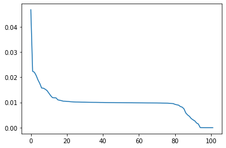

```python
pca_model = PCA().fit(xs)
plt.plot(pca_model.explained_variance_ratio_)
```

```python
pca_model.explained_variance_ratio_.cumsum()[40]
```

```
0.5374143770471586
```

#### At first, I want to use PCA to reduce the dimensions. However, I find out that PCA did not perform so well in capturing the information in this case. Later on, I ran the model without any dimension reduction and the accuracy scores look fine, so I decided to not use PCA.

### 2.6 Sperate Modeling Dataset and Testing Dataset

```python
data = df.loc['testing']
```

```python
df = df.loc['modeling']
```

```python
print('Testing Dataset:',data.shape)
print('Modeing Dataset:',df.shape)
```

```
Testing Dataset: (80000, 103)
Modeing Dataset: (338749, 103)
```

## 3. Build the Model

### 3.1 Create Training and Testing Datasets

```python
from sklearn.model_selection import train_test_split
```

```python
train, test = train_test_split(df, test_size=0.2, random_state = 1)
print("%d items in training data, %d in test data" % (len(train), len(test)))
```

```
270999 items in training data, 67750 in test data
```

```python
train_x = train.iloc[:,1:]
test_x = test.iloc[:,1:]
train_y = train['X1']
test_y = test['X1']
```

### 3.2 Linear Regression Model

```python
from sklearn.linear_model import LinearRegression
from sklearn.metrics import mean_squared_error as MSE
from sklearn.model_selection import cross_val_score
```

```python
linear_model = LinearRegression().fit(train_x,train_y)
```

#### Coefficient of Determination & Train RMSE & CV RMSE

```python
r_sq_linear = linear_model.score(train_x,train_y)
print('coefficient of determination:', round(r_sq_linear,4))
```

```
coefficient of determination: 0.8134
```

```python
train_y_linear = linear_model.predict(train_x)
RMSE_linear = (MSE(train_y,train_y_linear))**(1/2)
```

```python
print('Train RMSE for the linear model:', round(RMSE_linear,4))
```

```
Train RMSE for the linear model: 1.8916
```

```python
MSE_CV_Linear = - cross_val_score(linear_model, train_x, train_y, cv=10,
                                  scoring = 'neg_mean_squared_error', n_jobs=-1)
RMSE_CV_Linear = (MSE_CV_Linear.mean())**(1/2)
```

```python
print('CV RMSE for the linear model:', round(RMSE_CV_Linear,4))
```

```
CV RMSE for the linear model: 1.8924
```

#### Test Dataset

```python
linear_y_pred = linear_model.predict(test_x)
RMSE_linear_test = (MSE(test_y,linear_y_pred))**(1/2)
```

```python
print('Test RMSE for the linear model:', round(RMSE_linear_test,4))
```

```
Test RMSE for the linear model: 1.9024
```

### 3.3 Decision Tree Model

```python
from sklearn.tree import DecisionTreeRegressor
```

```python
tree = DecisionTreeRegressor().fit(train_x,train_y)
```

#### Coefficient of Determination & Train RMSE & CV RMSE

```python
r_sq_tree = tree.score(train_x,train_y)
print('coefficient of determination:', round(r_sq_tree,4))
```

```
coefficient of determination: 1.0
```

```python
train_y_tree = tree.predict(train_x)
RMSE_tree = (MSE(train_y,train_y_tree))**(1/2)
```

```python
print('Train RMSE for the Decision Tree model:', round(RMSE_tree,4))
```

```
Train RMSE for the Decision Tree model: 0.0
```

```python
MSE_CV_tree = - cross_val_score(tree, train_x, train_y, cv=10,
                                  scoring = 'neg_mean_squared_error', n_jobs=-1)
RMSE_CV_tree = (MSE_CV_tree.mean())**(1/2)
```

```python
print('CV RMSE for the Decision Tree model:', round(RMSE_CV_tree,4))
```

```
CV RMSE for the Decision Tree model: 2.0984
```

#### Test Dataset

```python
tree_y_pred = tree.predict(test_x)
RMSE_tree_test = (MSE(test_y,tree_y_pred))**(1/2)
```

```python
print('Test RMSE for the Decision Tree model:', round(RMSE_tree_test,4))
```

```
Test RMSE for the Decision Tree model: 2.1043
```

### 3.2 Random Forest Model

```python
from sklearn.ensemble import RandomForestRegressor
```

```python
rf = RandomForestRegressor(max_depth=50, min_samples_leaf = 0.01)
```

```python
rf.fit(train_x,train_y)
```

```
RandomForestRegressor(bootstrap=True, ccp_alpha=0.0, criterion='mse',
                      max_depth=50, max_features='auto', max_leaf_nodes=None,
                      max_samples=None, min_impurity_decrease=0.0,
                      min_impurity_split=None, min_samples_leaf=0.01,
                      min_samples_split=2, min_weight_fraction_leaf=0.0,
                      n_estimators=100, n_jobs=None, oob_score=False,
                      random_state=None, verbose=0, warm_start=False)
```

#### Coefficient of Determination & Train RMSE & CV RMSE

```python
r_sq_rf = rf.score(train_x,train_y)
print('coefficient of determination:', round(r_sq_rf,4))
```

```
coefficient of determination: 0.8203
```

```python
train_y_rf = rf.predict(train_x)
RMSE_rf = (MSE(train_y,train_y_rf))**(1/2)
```

```python
print('Train RMSE for the Random Forest model:', round(RMSE_rf,4))
```

```
Train RMSE for the Random Forest model: 1.8562
```

```python
MSE_CV_rf = - cross_val_score(rf, train_x, train_y, cv=5, scoring = 'neg_mean_squared_error', n_jobs=-1)
RMSE_CV_rf = (MSE_CV_rf.mean())**(1/2)
```

```python
print('CV RMSE for the Random Forest model:', round(RMSE_CV_rf,4))
```

```
CV RMSE for the Random Forest model: 1.8595
```

#### Test Dataset

```python
test_y_rf = rf.predict(test_x)
RMSE_rf_test = (MSE(test_y,test_y_rf))**(1/2)
```

```python
print('Test RMSE for the Random Forest model:', round(RMSE_rf_test,4))
```

```
Test RMSE for the Random Forest model: 1.8577
```

### 3.6 Gradient Boosting Regressor

```python
from sklearn.ensemble import GradientBoostingRegressor
```

```python
boosting = GradientBoostingRegressor()
```

```python
boosting.fit(train_x,train_y)
```

```
GradientBoostingRegressor(alpha=0.9, ccp_alpha=0.0, criterion='friedman_mse',
                          init=None, learning_rate=0.1, loss='ls', max_depth=3,
                          max_features=None, max_leaf_nodes=None,
                          min_impurity_decrease=0.0, min_impurity_split=None,
                          min_samples_leaf=1, min_samples_split=2,
                          min_weight_fraction_leaf=0.0, n_estimators=100,
                          n_iter_no_change=None, presort='deprecated',
                          random_state=None, subsample=1.0, tol=0.0001,
                          validation_fraction=0.1, verbose=0, warm_start=False)
```

#### Coefficient of Determination & Train RMSE & CV RMSE

```python
r_sq_boosting = boosting.score(train_x,train_y)
print('coefficient of determination:', round(r_sq_boosting,4))
```

```
coefficient of determination: 0.8453
```

```python
train_y_boosting = boosting.predict(train_x)
RMSE_boosting = (MSE(train_y,train_y_boosting))**(1/2)
```

```python
print('Train RMSE for the Gradient Boosting model:', round(RMSE_boosting,4))
```

```
Train RMSE for the Gradient Boosting model: 1.7226
```

```python
MSE_CV_boosting = - cross_val_score(boosting, train_x, train_y, cv=5, scoring = 'neg_mean_squared_error', n_jobs=-1)
RMSE_CV_boosting  = (MSE_CV_boosting .mean())**(1/2)
```

```python
print('CV RMSE for the Gradient Boosting model:', round(RMSE_CV_boosting,4))
```

```
CV RMSE for the Gradient Boosting model: 1.7251
```

#### Test Dateset

```python
test_y_boosting = boosting.predict(test_x)
RMSE_boosting_test = (MSE(test_y,test_y_boosting))**(1/2)
```

```python
print('Test RMSE for the Gradient Boosting model:', round(RMSE_boosting_test,4))
```

```
Test RMSE for the Gradient Boosting model: 1.7381
```

### 3.5 Voting Regressor

```python
from sklearn.ensemble import VotingRegressor
```

```python
linear = LinearRegression()
tree = DecisionTreeRegressor()
random = RandomForestRegressor(max_depth=50, min_samples_leaf = 0.01)
boosting = GradientBoostingRegressor()

regressors = [('Linear Regression', linear),('Decision Tree', tree),
              ('Random Forest',random),('Gradient Boosting', boosting)]
```

```python
for name, model in regressors:
    model.fit(train_x,train_y)
    y_pred = model.predict(test_x)
    print('{:s} : {:.3f}'.format(name,MSE(test_y, y_pred)**0.5))
```

```
Linear Regression : 1.902
Decision Tree : 2.108
Random Forest : 1.856
Gradient Boosting : 1.738
```

```python
vr = VotingRegressor(estimators = regressors)
vr.fit(train_x,train_y)
vr_y_pred = vr.predict(test_x)
```

```python
vr_y_pred
```

```
array([11.10071755, 14.51615254,  8.28364221, ...,  8.07610114,
        7.92409732, 10.73003751])
```

```python
r_sq_br = vr.score(train_x,train_y)
print('coefficient of determination:', round(r_sq_br,4))
```

```
coefficient of determination: 0.912
```

```python
train_y_vr = vr.predict(train_x)
RMSE_vr = (MSE(train_y,train_y_vr))**(1/2)
```

```python
print('Train RMSE for the Voting Regressor model:', round(RMSE_vr,4))
```

```
Train RMSE for the Voting Regressor model: 1.2989
```

```python
RMSE_vr_test = MSE(test_y,vr_y_pred)**0.5
print('Test RMSE for the Voting Regressor model:', round(RMSE_vr_test,4))
```

```
Test RMSE for the Voting Regressor model: 1.6683
```

## 4. Apply the Model to the Testing Dataset

```python
data.head()
```

|  | X1 | X4 | X5 | X6 | X11 | X13 | X15 | X19 | X21 | X22 | ... | X20_TX | X20_UT | X20_VA | X20_VT | X20_WA | X20_WI | X20_WV | X20_WY | X32_f | X32_w |
| --- | --- | --- | --- | --- | --- | --- | --- | --- | --- | --- | --- | --- | --- | --- | --- | --- | --- | --- | --- | --- | --- |
| 0 | NaN | 6000 | 6000 | 6000 | 10 | 68000.0 | 1900 | 430 | 28.31 | 0.0 | ... | 0 | 0 | 0 | 0 | 0 | 0 | 0 | 0 | 1 | 0 |
| 1 | NaN | 24000 | 24000 | 24000 | 8 | 110480.0 | 1900 | 945 | 16.03 | 0.0 | ... | 0 | 0 | 0 | 0 | 0 | 0 | 0 | 0 | 0 | 1 |
| 2 | NaN | 35000 | 35000 | 35000 | 10 | 86000.0 | 1900 | 195 | 32.49 | 0.0 | ... | 0 | 0 | 0 | 0 | 0 | 0 | 0 | 0 | 0 | 1 |
| 3 | NaN | 10000 | 10000 | 10000 | 10 | 30000.0 | 1900 | 921 | 32.96 | 0.0 | ... | 0 | 0 | 0 | 0 | 0 | 0 | 0 | 0 | 0 | 1 |
| 4 | NaN | 24000 | 24000 | 24000 | 10 | 82500.0 | 1900 | 196 | 31.03 | 0.0 | ... | 0 | 0 | 0 | 0 | 0 | 0 | 0 | 0 | 0 | 1 |

5 rows × 103 columns

```python
data.shape
```

```
(80000, 103)
```

```python
data = data.drop(['X1'],axis=1)
```

### 4.1 Apply Voting Regressor Model

```python
vr_final_test = vr.predict(data)
```

```python
result = pd.DataFrame(vr_final_test)
```

### 4.2 Save the Result as CSV file

```python
result
```

|  | 0 |
| --- | --- |
| 0 | 8.859627 |
| 1 | 4.148477 |
| 2 | 9.252308 |
| 3 | 11.823189 |
| 4 | 6.953311 |
| ... | ... |
| 79995 | 3.163833 |
| 79996 | 14.262353 |
| 79997 | 10.377495 |
| 79998 | 8.866548 |
| 79999 | 6.353864 |

80000 rows × 1 columns

```python
result.to_csv('result_from_12281155.csv', index = False, header=False)
```

### 4.3 Final Conclusion

#### Random Forest: 1.86 training error, 1.86 CV error, 1.86 testing error

#### Gradient Boosting: 1.72 training error, 1.73 CV error, 1.74 testing error

#### Voting Regressor: 1.30 training error, 1.67 testing error

#### Out of all the three models, Voting Regressor did the best job as its final result is the average of all the four other models. Decision Tree did a good job in the training dataset, but did the worst in the CV and testing, which means decision tree can easily has an overfitting problem. Linear Regression did an ok job as its training error and CV error are similar, and very close to the testing error. This means Linear Regressor does not an overfitting nor underfitting problem. Random Forest and Gradient Boosting did a better than both Linear Regression and Decision Tree as the RMSE are smaller, and they do not have an overfitting nor underfitting problem.